# Econometria - Atividade

Econometria - Atividade Francisco Piccolo 2020-12-08

## **Regressão Linear Múltipla com Dados do Mercado de Trabalho**

### **Introdução**

Neste post vou desenvolver um exercício comumente passado em aulas de econometria, envolvendo **regressão linear múltipla**. O dataset contêm dados do mercado de trabalho, com os seguintes campos:

- Ano
- Trimestre
- UF
- Situação da casa (house_situation)
- Gênero: 1 = Homem; 2 = Mulher
- Idade
- Raça: 1 = Branco; 2 = Preta; 3 = Amarela; 4 = Parda; 5 = Indígena
- Tipo de emprego
- Principal atividade
- Anos de estudo
- Rendimento mensal

Para realizar este exercício, irei utilizar os seguintes pacotes:

```r
# install.packages("tidyverse") >> Para instalar o pacote caso não o tenha instalado
library(tidyverse)  # Para chamar o pacote
library(patchwork)
library(readxl)
library(GGally)
library(feasts)
```

Com o código abaixo, irei trazer o dataset para o R.

```r
dataset_1 <- readxl::read_excel(path = "C:/Users/fppicco/Desktop/R/Github/franciscopiccolo.github.io/datasets/2020-12-06-trabalho-econometria-gabriela/dataset_1.xlsx")
```

### **Banco de Dados**

Abaixo, vamos fazer uma análise exploratória dos dados para conseguir determinar o modelo ideal de regressão múltipla.

#### **Representatividade de cada grupo na pesqusia**

##### **Raça**

```r
dataset_1 %>%
  group_by(race) %>%
  summarise(Qty = n()) %>%
  knitr::kable(format.args = list(decimal.mark = ",", big.mark = "."))
```

| race | Qty |
| --- | --- |
| amarelo | 71 |
| branco | 4.749 |
| indigena | 79 |
| parda | 8.428 |
| preto | 1.888 |

Como o grupo ‘amarelo’ e ‘indígena’ contém um baixo número de registros, irei retirá-los para simplificar o modelo.

```r
dataset_1 <-
  dataset_1 %>%
  filter(race %in% c("branco","parda","preto"))
```

##### **Gênero**

```r
dataset_1 %>%
  group_by(gender) %>%
  summarise(count = n()) %>%
  knitr::kable(format.args = list(decimal.mark = ",", big.mark = "."))
```

| gender | count |
| --- | --- |
| homem | 14.527 |
| mulher | 538 |

Nota-se que homens estão bem mais representados na amostra (~96% do total). Talvez seja melhor não usar esta variável, visto que está desbalançeada.

```r
dataset_1 <-
  dataset_1 %>%
  select(-gender)  # Retirando o gênero
```

##### **Situação do Domicílio (Urbana ou Rural)**

```r
dataset_1 %>%
  group_by(house_situation) %>%
  summarise(count = n()) %>%
  knitr::kable(format.args = list(decimal.mark = ",", big.mark = "."))
```

| house_situation | count |
| --- | --- |
| rural | 2.462 |
| urbana | 12.603 |

Aproximadamente 83% dos registros na amostra são de domicílios urbanos. Porém irei manter esta variável, pois pode ser bastante explicativa para a variável dependente (rendimento mensal).

##### **Anos de Estudo**

```r
dataset_1 %>%
  group_by(years_of_study) %>%
  summarise(count = n()) %>%
  knitr::kable(format.args = list(decimal.mark = ",", big.mark = "."))
```

| years_of_study | count |
| --- | --- |
| 0 | 393 |
| 1 | 187 |
| 2 | 240 |
| 3 | 456 |
| 4 | 636 |
| 5 | 1.784 |
| 6 | 1.385 |
| 7 | 866 |
| 8 | 844 |
| 9 | 1.884 |
| 10 | 699 |
| 11 | 584 |
| 12 | 3.978 |
| 13 | 199 |
| 14 | 126 |
| 15 | 130 |
| 16 | 674 |

Esta variável parece importante para explicar o rendimento mensal das pessoas do dataset. Ela será mantida no modelo, porém será agrupada nos seguintes grupos:

- 0 Anos
- Até 6 Anos
- Até 12 Anos
- Acima de 12 Anos

```r
dataset_1 %>%
  mutate(years_of_study_grp = case_when(years_of_study == 0 ~ "zero",
                                        years_of_study <= 6 ~ "até_6",
                                        years_of_study <= 12 ~ "até_12",
                                        TRUE ~ "acima_de_12")) -> dataset_1
```

Com este agrupamento dos anos de estudo, vamos ver como fica a distribuição.

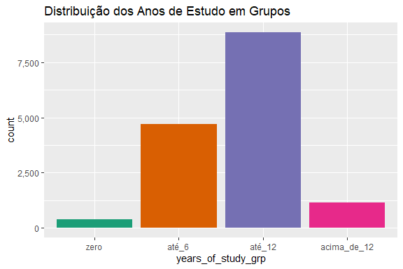

```r
dataset_1 %>%
  mutate(count = 1,
         years_of_study_grp = fct_relevel(years_of_study_grp, levels = c("zero","até_6","até_12","acima_de_12"))) %>%
  ggplot2::ggplot()+
  geom_col(mapping = aes(x = years_of_study_grp, y = count, fill = years_of_study_grp))+
  theme(legend.position = "none",
        legend.title = element_blank())+
  scale_fill_brewer(type = "qual", palette = 2)+
  scale_y_continuous(labels = scales::comma)+
  labs(title = "Distribuição dos Anos de Estudo em Grupos")
```

Após verificar as variáveis separadamente, vamos ajustar o dataset para manter apenas as que serão relevantes para o modelo.

- Situação do domicílio (house_situation): Urbano ou Rural
- Idade (age)
- Raça (race)
- Anos de estudo agrupado (years_of_study_grp)
- Rendimento Mensal (montly_earnings)

```r
dataset_1 %>%
  select(house_situation, age, race, years_of_study_grp, monthly_earning) -> dataset_1_adj
```

O modelo será uma regressão linear múltipla tendo ‘monthly_earning’ como variável dependente. O modelo poderá ser descrito de acordo com a equação abaixo:

$$\hat{Y} = \hat{\beta_1}X_1 + \hat{\beta_2}X_2 + \hat{\beta_3}X_3 + \hat{\beta_4}X_4 + \mu$$

Vamos ver separadamente qual a correlação da variável dependente com cada uma das variáveis independentes, para poder antever os resultados do modelo.

##### **Rendimento Mensal e Raça**

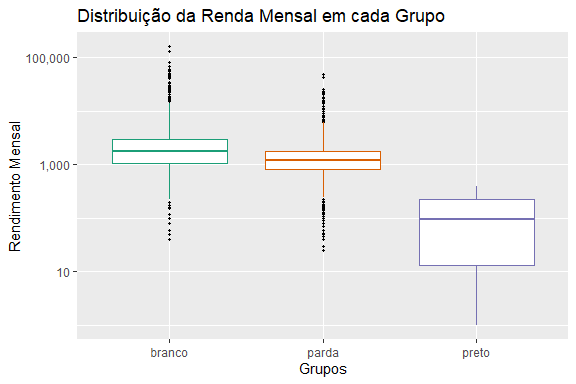

```r
dataset_1_adj %>%
  ggplot2::ggplot()+
  geom_boxplot(mapping = aes(x = race, y = monthly_earning, color = race), outlier.shape = 20, outlier.color = "black")+
  scale_y_log10(labels = scales::comma)+
  scale_color_brewer(type = "qual", palette = 2)+
  theme(legend.position = "none",
        legend.title = element_blank())+
  labs(title = "Distribuição da Renda Mensal em cada Grupo",
       y = "Rendimento Mensal",
       x = "Grupos")
```

A renda possuí outliers, por isso usar o **log 10** no eixo y se faz necessário. A renda mensal média do grupo ‘brancos’ é maior que as dos grupos ‘pardos’ e ‘pretos’. Abaixo a tabela mostra os valores do gráfico acima:

```r
dataset_1 %>%
  group_by(race) %>%
  summarise(min = min(monthly_earning),
            max = max(monthly_earning),
            mean = mean(monthly_earning),
            sd = sd(monthly_earning)) %>%
  knitr::kable(format.args = list(decimal.mark = ",", big.mark = "."))
```

| race | min | max | mean | sd |
| --- | --- | --- | --- | --- |
| branco | 0 | 160.000 | 4.914,2563 | 10.377,453 |
| parda | 0 | 49.000 | 1.446,1359 | 2.017,615 |
| preto | 0 | 391 | 117,1833 | 116,601 |

Os valores zerados de renda mensal parecem estranhos. A princípios iremos mantê-los e caso necessário iremos retirá-los para ver o impacto no modelo.

##### **Rendimento Mensal e Age**

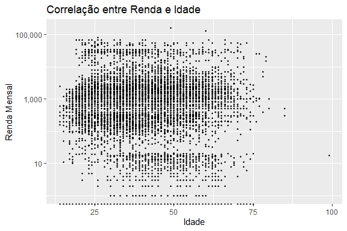

```r
dataset_1_adj %>%
  ggplot2::ggplot()+
  geom_point(mapping = aes(x = age, y = monthly_earning), shape = 20)+
  scale_y_log10(labels = scales::comma)+
  labs(title = "Correlação entre Renda e Idade",
       y = "Renda Mensal",
       x = "Idade")
```

Nota-se que idade não será muito relevante para determinar variações na renda, porém talvez a idade esteja alinhada com os anos de estudo. Vamos ver abaixo estas duas variáveis.

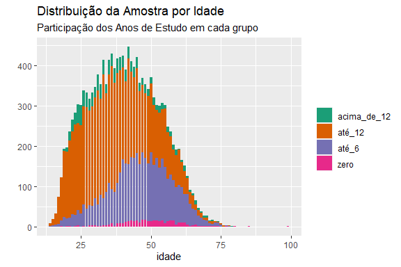

```r
dataset_1_adj %>%
  mutate(count = 1) %>%
  ggplot2::ggplot()+
  geom_col(mapping = aes(x = age, y = count, fill = years_of_study_grp))+
  scale_fill_brewer(type = "qual", palette = 2)+
  theme(legend.title = element_blank())+
  labs(title = "Distribuição da Amostra por Idade",
       subtitle = "Participação dos Anos de Estudo em cada grupo",
       y = "",
       x = "idade")
```

##### **Rendimento Mensal e Anos de Estudo**

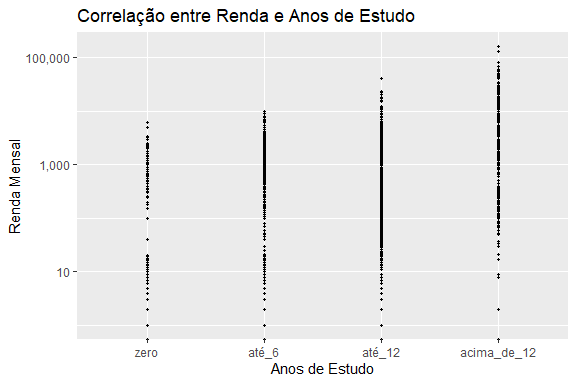

```r
dataset_1_adj %>%
  mutate(years_of_study_grp = fct_relevel(years_of_study_grp, levels = c("zero","até_6","até_12","acima_de_12"))) %>%
  ggplot2::ggplot()+
  geom_point(mapping = aes(x = years_of_study_grp, y = monthly_earning), shape = 20)+
  scale_y_log10(labels = scales::comma)+
  labs(title = "Correlação entre Renda e Anos de Estudo",
       y = "Renda Mensal",
       x = "Anos de Estudo")
```

Aparentemente há uma relação entre anos de estudos e rendimento mensal, como era de se esperar. Acredito que esta será a principal variável do modelo (com menor valor-p).

##### **Rendimento Mensal e Situação do Domicílio**

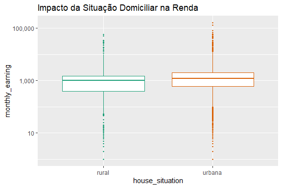

```r
dataset_1_adj %>%
  ggplot2::ggplot()+
  geom_boxplot(mapping = aes(x = house_situation, y = monthly_earning, color = house_situation), outlier.shape = 20)+
  scale_y_log10(labels = scales::comma)+
  scale_color_brewer(type = "qual", palette = 2)+
  theme(legend.position = "none",
        legend.title = element_blank())+
  labs(title = "Impacto da Situação Domiciliar na Renda")
```

A situação domiciliar parece impactar na determinação da renda, porém fortemente influenciada por outliers (que está mais concentrado nos domicílios urbanos, que representam mais de 80% dos registros do dataset). Vamos verificar se há correlação entre a situação domiciliar e os anos de estudos.

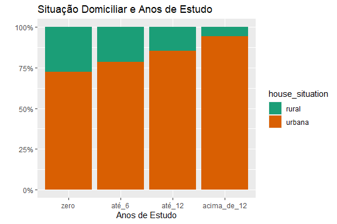

```r
dataset_1_adj %>%
  mutate(years_of_study_grp = fct_relevel(years_of_study_grp, levels = c("zero","até_6","até_12","acima_de_12"))) %>%
  mutate(count = 1) %>%
  ggplot2::ggplot()+
  geom_col(mapping = aes(x = years_of_study_grp, y = count, fill = house_situation), position = "fill")+
  scale_fill_brewer(type = "qual", palette = 2)+
  scale_y_continuous(labels = scales::percent)+
  labs(title = "Situação Domiciliar e Anos de Estudo",
       y = "",
       x = "Anos de Estudo")
```

Veja que a população rural, como era de se esperar, possui um menor tempo de educação formal, podendo gerar uma autocorrelação entre estas variáveis explicativas. Porém, vamos deixá-la para ver o impacto, e depois se necessário uma delas pode ser removida.

## **Modelo**

O modelo de regressão conforme informado anteriormente, buscará explicar variações na variável ‘monthly_earning’ usando as variáveis explicativas estudadas anteriormente.

### **Modelo 1: Rendimento vs Anos de Estudo**

```r
dataset_1 %>%
  lm(formula = "monthly_earning ~ (years_of_study)") %>%
  summary() %>%
  pander::pander()
```

|  | Estimate | Std. Error | t value | Pr(>\|t\|) |
| --- | --- | --- | --- | --- |
| **(Intercept)** | -2305 | 120.6 | -19.1 | 2.125e-80 |
| **years_of_study** | 542.8 | 12.83 | 42.31 | 0 |

Fitting linear model: “monthly_earning ~ (years_of_study)”

| Observations | Residual Std. Error | $R^2$ | Adjusted $R^2$ |
| --- | --- | --- | --- |
| 15065 | 5933 | 0.1062 | 0.1062 |

R² baixo (pouco poder explicativo), porém valor-t alto e valor-p baixo, indicando significância estatística.

### **Modelo 2: Rendimento vs Raça**

Vamos transformar raça em variável binária, sendo 1 = Branco e 0 = Negros e Pardos.

```r
dataset_1 %>%
  mutate(dummy_race = case_when(race == "branco" ~ 1,
                                TRUE ~ 0)) %>%
  lm(formula = monthly_earning ~ (dummy_race)) %>%
  summary() %>%
  pander::pander()
```

|  | Estimate | Std. Error | t value | Pr(>\|t\|) |
| --- | --- | --- | --- | --- |
| **(Intercept)** | 1203 | 59.41 | 20.25 | 5.67e-90 |
| **dummy_race** | 3711 | 105.8 | 35.08 | 3.554e-259 |

Fitting linear model: monthly_earning ~ (dummy_race)

| Observations | Residual Std. Error | $R^2$ | Adjusted $R^2$ |
| --- | --- | --- | --- |
| 15065 | 6034 | 0.07551 | 0.07545 |

Novamente R² baixo, porém com valor-p e valor-t indicando significância estatística. Resultados indicam impacto positivo da raça no rendimento mensal, conforme indicado nos gráfico box-plot visto anteriormente. Vale destacar que o modelo de regressão é bastante impactado por outliers (pois utiliza média simples para minimizar os resíduos), por isso os outliers de renda no grupo “Brancos” está influenciando no resultado.

### **Modelo 3: Rendimento vs Situação Domiciliar**

```r
dataset_1 %>%
  lm(formula = monthly_earning ~ (house_situation)) %>%
  summary() %>%
  pander::pander()
```

|  | Estimate | Std. Error | t value | Pr(>\|t\|) |
| --- | --- | --- | --- | --- |
| **(Intercept)** | 1375 | 126.2 | 10.9 | 1.422e-27 |
| **house_situationurbana** | 1192 | 137.9 | 8.644 | 5.968e-18 |

Fitting linear model: monthly_earning ~ (house_situation)

| Observations | Residual Std. Error | $R^2$ | Adjusted $R^2$ |
| --- | --- | --- | --- |
| 15065 | 6260 | 0.004936 | 0.00487 |

R² novamente baixo. Porém a variável mostra impacto positivo para domicílios urbanos, conforme visto no box-plot desta variável com a renda mensal.

### **Modelo Final**

No modelo final, será retirado os valores zerados de renda mensal.

```r
# Criando variável com resultado do modelo de regressão múltipla
dataset_1 %>%
  filter(monthly_earning > 0) -> dataset_1

dataset_1 %>%
  mutate(dummy_race = case_when(race == "branco" ~ 1,
                                TRUE ~ 0)) %>%
  lm(formula = monthly_earning ~ (years_of_study + dummy_race)) -> final_model
```

```r
final_model %>%
  summary() %>%
  pander::pander()
```

|  | Estimate | Std. Error | t value | Pr(>\|t\|) |
| --- | --- | --- | --- | --- |
| **(Intercept)** | -2809 | 123.6 | -22.72 | 2.646e-112 |
| **years_of_study** | 496.6 | 13.2 | 37.61 | 2.545e-295 |
| **dummy_race** | 3121 | 106.6 | 29.28 | 3.843e-183 |

Fitting linear model: monthly_earning ~ (years_of_study + dummy_race)

| Observations | Residual Std. Error | $R^2$ | Adjusted $R^2$ |
| --- | --- | --- | --- |
| 14369 | 5870 | 0.1598 | 0.1597 |

Verificando fit do modelo:

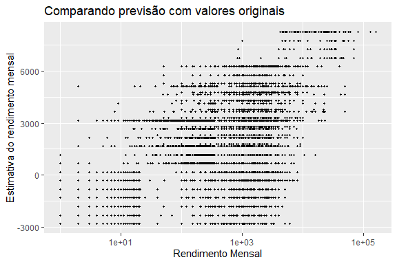

```r
# Adicionando os valores estimados ao dataset original
dataset_1$fitted_2 <- final_model$fitted.values

# Plotando os resultados
dataset_1 %>%
  ggplot2::ggplot()+
  geom_point(mapping = aes(x = monthly_earning, y = fitted_2), shape = 20)+
  scale_x_log10()+
  labs(title = "Comparando previsão com valores originais",
       x = "Rendimento Mensal",
       y = "Estimativa do rendimento mensal")
```

Verificando os resíduos:

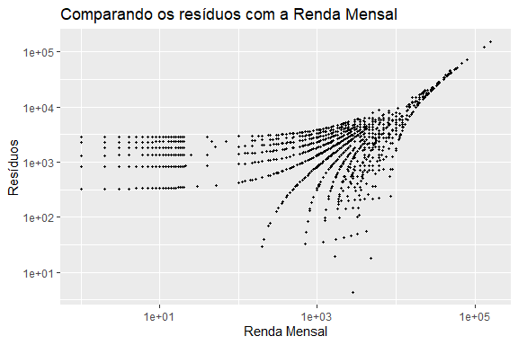

```r
# Adicionando os resíduos no dataset original
dataset_1$residuals <- final_model$residuals

dataset_1 %>%
  ggplot2::ggplot()+
  geom_point(mapping = aes(x = monthly_earning, y = residuals), shape = 20)+
  scale_y_log10()+
  scale_x_log10()+
  labs(title = "Comparando os resíduos com a Renda Mensal",
       x = "Renda Mensal",
       y = "Resíduos")
```